# scGraphVerse Case Study: Zero-Inflated Simulation and GRN Inference

Francesco Cecere

12 ottobre 2025

# 1 Introduction

scGraphVerse is a modular and extensible R package for constructing, comparing, and visualizing gene regulatory networks (GRNs) from single-cell RNAseq data. It includes several inference algorithms, utilities, and visualization functions.

Single-cell data presents unique challenges: high sparsity, batch variation, and the need to distinguish shared versus condition-specific regulation. scGraphVerse helps address these through multi-method inference consensus. It starts with SingleCellExperiment, Seurat or matrix-based objects, enabling flexible pipelines across diverse experimental setups.

## 1.1 Why use scGraphVerse?

While several GRN inference packages exist in Bioconductor (e.g. SCENIC), most are limited to single-method inference or lack support for multi-condition, multi-replicate, and multi-method comparisons. scGraphVerse adds value by:

1. Supporting multiple inference algorithms, including GENIE3, GRNBoost2, ZILGM, PCzinb, and Joint Random Forests (JRF).
2. Providing joint modeling of GRNs across multiple conditions via JRF
3. Enabling benchmarking simulations from known ground-truth GRNs with customizable ZINB-based count matrix generation.
4. Offering community analysis, including consensus GRNs and databases integration (e.g. PubMed and STRINGdb).

## 1.2 How scGraphVerse works

The typical scGraphVerse workflow begins with one or more count matrix, or objects like SingleCellExperiment or Seurat. These are passed to the core function infer_networks(), which runs the selected inference methods and returns an adjacency matrix or list of matrices.

For benchmarking or teaching purposes, synthetic datasets can be generated using zinb_simdata() based on a known adjacency matrix. This supports method comparison across early, late, and joint integration strategies using earlyj() and compare_consensus().

An end-to-end workflow, from network inference to community detection and consensus visualization, is provided in the rest of vignettes.

As intended for both high-throughput analysis and intuitive usage, scGraphVerse supports custom workflows using its modular functions.

# 2 Simulation study

In this simulation study, we use **scGraphVerse** to:

1. Define a ground-truth regulatory network from high-confidence interactions.
2. Simulate zero-inflated scRNA-seq count data that respects the ground truth.
3. Infer gene regulatory networks using **GENIE3**.
4. Evaluate performance with ROC curves, precision–recall scores, and community similarity.
5. Build consensus networks and perform edge mining.

# 3 1. Load Ground-Truth Network

We use a pre-computed toy adjacency matrix (`toy_adj_matrix`) as our ground truth network. This matrix represents known regulatory relationships between genes and serves as the reference for evaluating network inference performance.

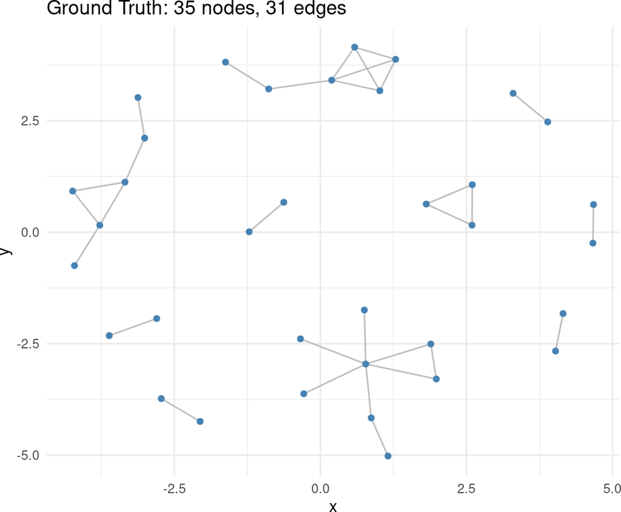

```r
# Load the toy ground truth adjacency matrix
data(toy_adj_matrix)
adj_truth <- toy_adj_matrix

# Visualize network
if (requireNamespace("igraph", quietly = TRUE) &&
    requireNamespace("ggraph", quietly = TRUE)) {
    gtruth <- igraph::graph_from_adjacency_matrix(adj_truth,mode="undirected")
    ggraph::ggraph(gtruth, layout = "fr") +
        ggraph::geom_edge_link(color = "gray") +
        ggraph::geom_node_point(color = "steelblue") +
        ggplot2::ggtitle(paste0(
            "Ground Truth: ",
            igraph::vcount(gtruth),
            " nodes, ",
            igraph::ecount(gtruth),
            " edges"
        )) +
        ggplot2::theme_minimal()
}
```

# 4 2. Simulating Zero-Inflated Count Data

**Key simulation parameters:** - `mu_range`: Different mean expression levels across conditions - `theta`: Overdispersion parameter (lower = more variable)  
- `pi`: Zero-inflation probability (dropout rate) - `depth_range`: Sequencing depth variation per cell

```r
# Simulation parameters
nodes <- nrow(adj_truth)
sims <- zinb_simdata(
    n = 50,
    p = nodes,
    B = adj_truth,
    mu_range = list(c(1, 4), c(1, 7)),
    mu_noise = c(1, 3),
    theta = c(1, 0.7),
    pi = c(0.2, 0.2),
    kmat = 2,
    depth_range = c(0.8 * nodes * 3, 1.2 * nodes * 3)
)
# Transpose to cells × genes
count_matrices <- lapply(sims, t)
```

# 5 3. Inferring Networks with GENIE3

**Note:** The package now uses Bioconductor data structures: - `count_matrices` is now a `MultiAssayExperiment` (MAE) object - Network outputs are stored in `SummarizedExperiment` (SE) objects

**GENIE3 workflow:** 1. Create a MAE object from the count matrices list 2. For each target gene, build random forest model using all other genes as predictors 3. Extract feature importance scores as edge weights 4. Generate weighted adjacency matrices stored in a SummarizedExperiment 5. Symmetrize the matrices using mean weights to create undirected networks

```r
# Create MultiAssayExperiment from count matrices
mae <- create_mae(count_matrices)

# Infer networks
networks_joint <- infer_networks(
    count_matrices_list = mae,
    method = "GENIE3",
    nCores = 1
)

# Generate weighted adjacency matrices (returns SummarizedExperiment)
wadj_se <- generate_adjacency(networks_joint)

# Symmetrize weights (returns SummarizedExperiment)
swadj_se <- symmetrize(wadj_se, weight_function = "mean")
```

# 6 4. ROC Curve and AUC

Now we evaluate how well our inferred networks recover the ground-truth regulatory relationships using ROC curve analysis. The ROC curve plots True Positive Rate (sensitivity) against False Positive Rate (1-specificity) across different edge weight thresholds. A perfect classifier would achieve AUC = 1.0, while random guessing gives AUC = 0.5.

**ROC Analysis Steps:** 1. Use continuous edge weights from symmetrized adjacency matrices 2. Compare against binary ground-truth network 3. Calculate Area Under Curve (AUC) as overall performance metric 4. Higher AUC indicates better recovery of true regulatory edges

```r
if (requireNamespace("pROC", quietly = TRUE)) {
    roc_res <- plotROC(
        swadj_se,
        adj_truth,
        plot_title = "ROC Curve: GENIE3 Network Inference",
        is_binary = FALSE
    )
    roc_res$plot
    auc_joint <- roc_res$auc
}
```

[output not shown]

## 6.1 4.1. Precision–Recall and Graph Visualization

To convert our continuous edge weights into binary networks, we need to determine appropriate cutoff thresholds. The `cutoff_adjacency()` function uses a data-driven approach: it creates shuffled versions of our count data, infers networks from these null datasets, and sets the threshold at the 95th percentile of shuffled edge weights. This ensures we keep only edges that are much stronger than expected by random chance.

**Cutoff Method:** 1. Generate shuffled count matrices (randomize gene expression profiles) 2. Run GENIE3 on shuffled data to get null distribution of edge weights 3. Set threshold at 95th percentile of shuffled weights 4. Apply threshold to original networks to get binary adjacency matrices 5. Calculate precision metrics: TPR (sensitivity), FPR, Precision, F1-score

```r
# Binary cutoff at 95th percentile (returns SummarizedExperiment)
binary_se <- cutoff_adjacency(
    count_matrices = mae,
    weighted_adjm_list = swadj_se,
    n = 1,
    method = "GENIE3",
    quantile_threshold = 0.95,
    nCores = 1,
    debug = TRUE
)
```

```
#> [Method: GENIE3] Matrix 1 → Cutoff = 0.06580
#> [Method: GENIE3] Matrix 2 → Cutoff = 0.06480
```

```r
# Precision scores
pscores_joint <- pscores(adj_truth, binary_se)
```

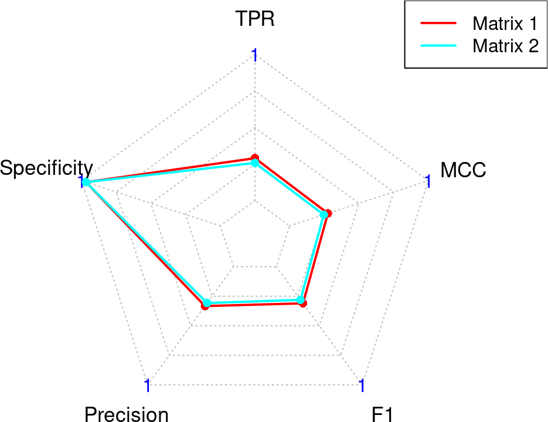

```r
head(pscores_joint)
```

```
#> $Statistics
#>   Predicted_Matrix TP  TN FP FN       TPR        FPR Precision        F1
#> 1         Matrix 1  9 546 18 22 0.2903226 0.03191489 0.3333333 0.3103448
#> 2         Matrix 2  8 546 18 23 0.2580645 0.03191489 0.3076923 0.2807018
#>         MCC
#> 1 0.2759115
#> 2 0.2458518
#>
#> $Radar
#> $Radar$data
#>                TPR Specificity Precision        F1       MCC
#> Max      1.0000000   1.0000000 1.0000000 1.0000000 1.0000000
#> Min      0.0000000   0.0000000 0.0000000 0.0000000 0.0000000
#> Matrix 1 0.2903226   0.9680851 0.3333333 0.3103448 0.2759115
#> Matrix 2 0.2580645   0.9680851 0.3076923 0.2807018 0.2458518
#>
#> $Radar$plot
```

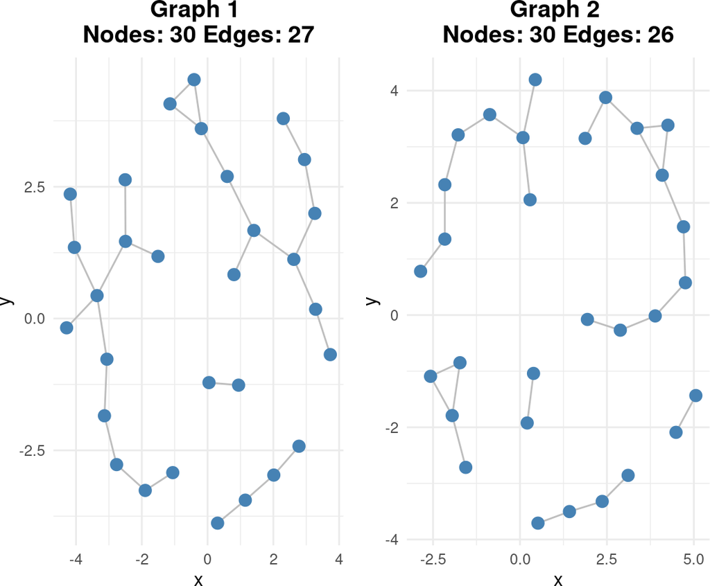

```r
# Network plot
if (requireNamespace("ggraph", quietly = TRUE)) {
    plotg(binary_se)
}
```

# 7 5. Consensus Networks and Community Similarity

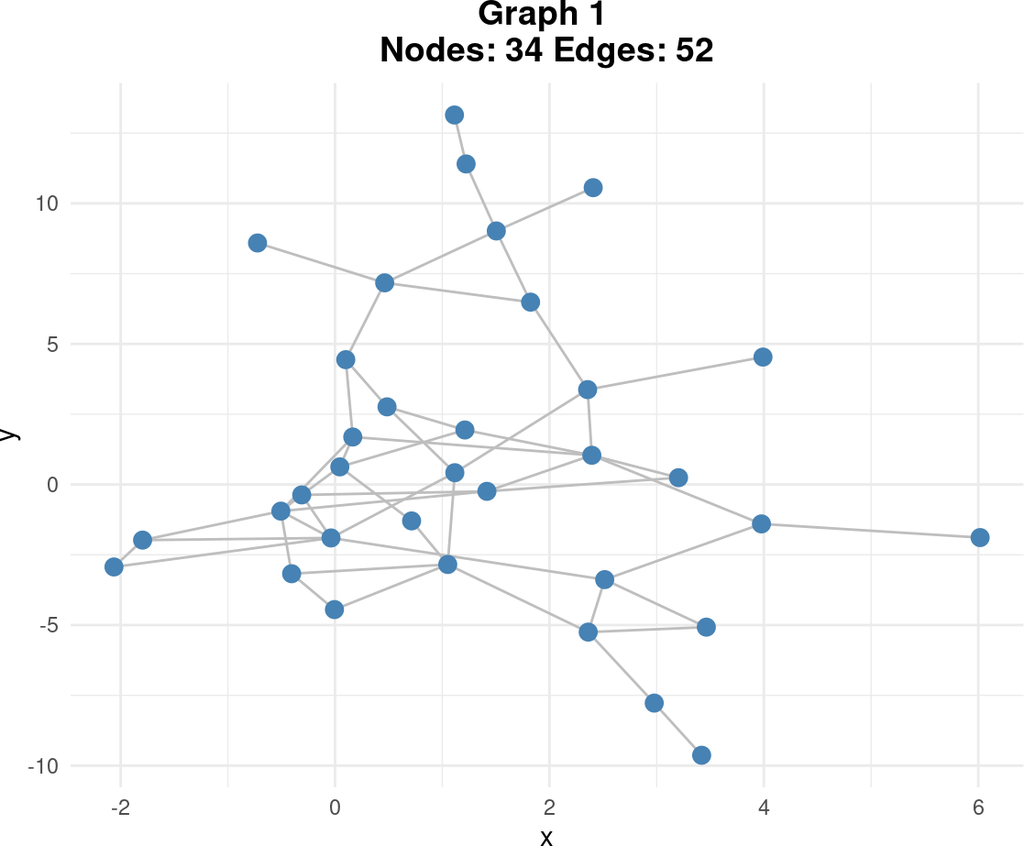

```r
# Consensus matrix (returns SummarizedExperiment)
consensus <- create_consensus(binary_se, method = "vote")

# Plot consensus network
if (requireNamespace("ggraph", quietly = TRUE)) {
    plotg(consensus)
}
```

```
#> $tp_edges
#>  [1] "ACTG1-ARPC3"  "ACTG1-CFL1"   "ACTG1-PFN1"   "BTF3-NACA"    "CD3D-CD3E"
#>  [6] "CD3E-HLA-A"   "CD74-CXCR4"   "COX4I1-COX7C" "EEF1A1-EEF1D" "EEF2-GNB2L1"
#> [11] "EEF2-UBA52"   "FOS-JUN"      "FTH1-FTL"     "GNB2L1-UBA52" "HLA-C-HLA-E"
#> [16] "MYL12B-MYL6"
#>
#> $fp_edges
#>  [1] "ACTG1-FTH1"    "ACTG1-FTL"     "ACTG1-HLA-B"   "ARPC2-NACA"
#>  [5] "ARPC3-FTH1"    "BTF3-EIF3K"    "BTF3-JUN"      "CD3D-HLA-A"
#>  [9] "CD3E-EIF1"     "CD3E-EIF3K"    "CD3E-HLA-C"    "CD3E-MYL12B"
#> [13] "CD74-PFN1"     "CFL1-FTL"      "CFL1-HLA-A"    "CFL1-MYL6"
#> [17] "COX4I1-NACA"   "CXCR4-EEF2"    "CXCR4-JUNB"    "CXCR4-PFN1"
#> [21] "EEF1A1-JUN"    "EEF1A1-MYL12B" "EEF1D-EIF1"    "EEF1D-HLA-B"
#> [25] "EEF2-EIF4A2"   "EEF2-HLA-B"    "EIF1-MYL6"     "EIF3K-HLA-B"
#> [29] "EIF3K-PABPC1"  "EIF4A2-MYL6"   "FTL-GNB2L1"    "FTL-HLA-A"
#> [33] "FTL-MYL12B"    "HLA-C-PFN1"    "JUN-NACA"      "JUNB-TMSB4X"
#>
#> $fn_edges
#>  [1] "ACTG1-ARPC2"   "ACTG1-MYL6"    "ACTG1-TMSB4X"  "ARPC2-ARPC3"
#>  [5] "EIF1-EIF3K"    "EIF1-GNB2L1"   "EIF4A2-PABPC1" "FOS-JUNB"
#>  [9] "HLA-A-HLA-B"   "HLA-A-HLA-C"   "HLA-A-HLA-E"   "HLA-B-HLA-C"
#> [13] "HLA-B-HLA-E"   "JUN-JUNB"      "UBA52-UBC"
#>
#> $consensus_graph
#> IGRAPH 02a04da UN-- 35 52 --
#> + attr: name (v/c)
#> + edges from 02a04da (vertex names):
#>  [1] ACTG1 --ARPC3  ACTG1 --CFL1   ACTG1 --FTH1   ACTG1 --FTL    ACTG1 --HLA-B
#>  [6] ACTG1 --PFN1   ARPC2 --NACA   ARPC3 --FTH1   BTF3  --EIF3K  BTF3  --JUN
#> [11] BTF3  --NACA   CD3D  --CD3E   CD3D  --HLA-A  CD3E  --EIF1   CD3E  --EIF3K
#> [16] CD3E  --HLA-A  CD3E  --HLA-C  CD3E  --MYL12B CD74  --CXCR4  CD74  --PFN1
#> [21] CFL1  --FTL    CFL1  --HLA-A  CFL1  --MYL6   COX4I1--COX7C  COX4I1--NACA
#> [26] CXCR4 --EEF2   CXCR4 --JUNB   CXCR4 --PFN1   EEF1A1--EEF1D  EEF1A1--JUN
#> [31] EEF1A1--MYL12B EEF1D --EIF1   EEF1D --HLA-B  EEF2  --EIF4A2 EEF2  --GNB2L1
#> [36] EEF2  --HLA-B  EEF2  --UBA52  EIF1  --MYL6   EIF3K --HLA-B  EIF3K --PABPC1
#> + ... omitted several edges
#>
#> $reference_graph
#> IGRAPH 86f7e85 UN-- 35 31 --
#> + attr: name (v/c)
#> + edges from 86f7e85 (vertex names):
#>  [1] ACTG1 --ARPC2  ACTG1 --ARPC3  ACTG1 --CFL1   ACTG1 --MYL6   ACTG1 --PFN1
#>  [6] ACTG1 --TMSB4X ARPC2 --ARPC3  BTF3  --NACA   CD3D  --CD3E   CD3E  --HLA-A
#> [11] CD74  --CXCR4  COX4I1--COX7C  EEF1A1--EEF1D  EEF2  --GNB2L1 EEF2  --UBA52
#> [16] EIF1  --EIF3K  EIF1  --GNB2L1 EIF4A2--PABPC1 FOS   --JUN    FOS   --JUNB
#> [21] FTH1  --FTL    GNB2L1--UBA52  HLA-A --HLA-B  HLA-A --HLA-C  HLA-A --HLA-E
#> [26] HLA-B --HLA-C  HLA-B --HLA-E  HLA-C --HLA-E  JUN   --JUNB   MYL12B--MYL6
#> [31] UBA52 --UBC
#>
#> $edge_colors
#>  [1] "blue" "red"  "red"  "blue" "red"  "blue" "blue" "red"  "red"  "red"
#> [11] "red"  "red"  "red"  "red"  "red"  "blue" "blue" "blue" "red"  "blue"
#> [21] "red"  "red"  "blue" "blue" "blue" "blue" "blue" "red"  "blue" "red"
#> [31] "blue"
#>
#> $use_stringdb
#> [1] FALSE
```

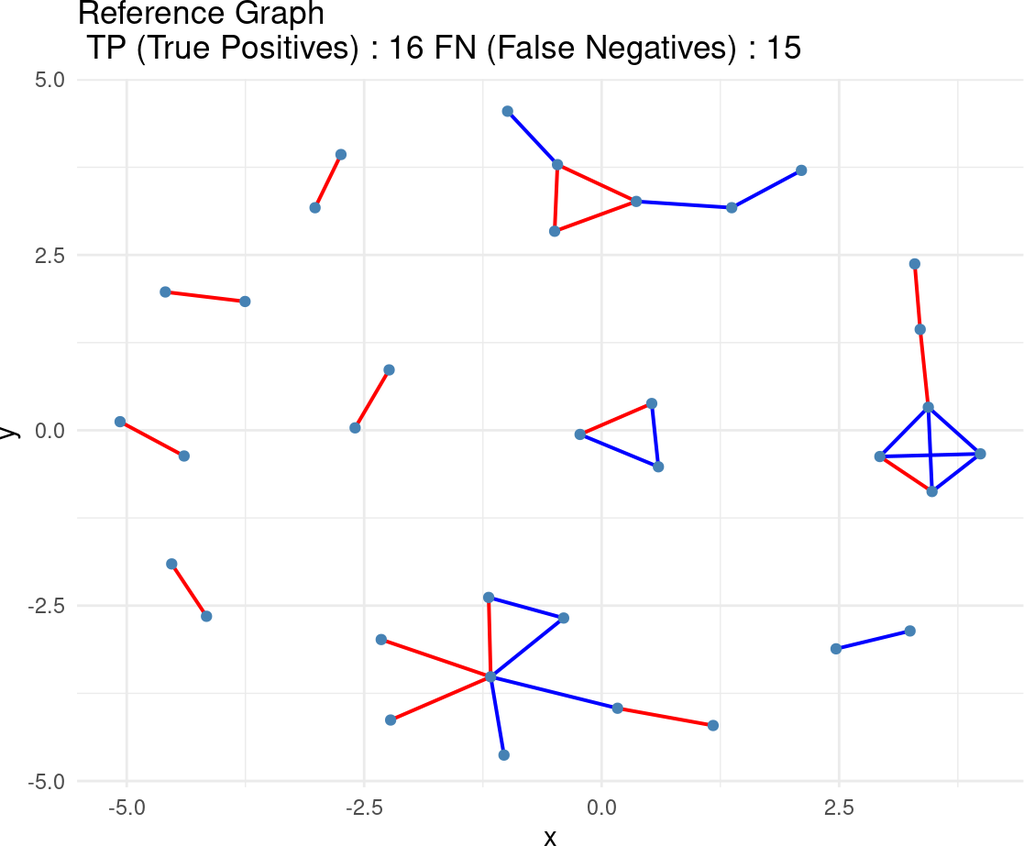

```r
# Compare consensus to truth using classify_edges and plot_network_comparison
if (requireNamespace("ggplot2", quietly = TRUE) &&
    requireNamespace("ggraph", quietly = TRUE)) {
    # Wrap toy_adj_matrix in a SummarizedExperiment for classify_edges
    adj_truth_se <- build_network_se(list(ground_truth = adj_truth))

    # classify_edges expects SummarizedExperiment objects
    edge_classification <- classify_edges(
        consensus_matrix = consensus,
        reference_matrix = adj_truth_se
    )

    print(edge_classification)

    # Visualize network comparison (show_fp = FALSE to hide false positives)
    comparison_plot <- plot_network_comparison(
        edge_classification = edge_classification,
        show_fp = FALSE
    )

    print(comparison_plot)
}
```

Community detection identifies groups of highly interconnected genes that likely share biological functions or regulatory mechanisms. We’ll detect communities in both our inferred consensus network and the ground-truth network, then compare their similarity using several metrics.

**Community Detection Steps:** 1. Apply Louvain algorithm to identify network modules 2. Compare community assignments using multiple similarity measures: - **Variation of Information (VI)**: Lower values = more similar - **Normalized Mutual Information (NMI)**: Higher values = more similar - **Adjusted Rand Index (ARI)**: Higher values = more similar

Now we’ll detect communities in our ground-truth network to establish the reference community structure:

```
#> Detecting communities...
```

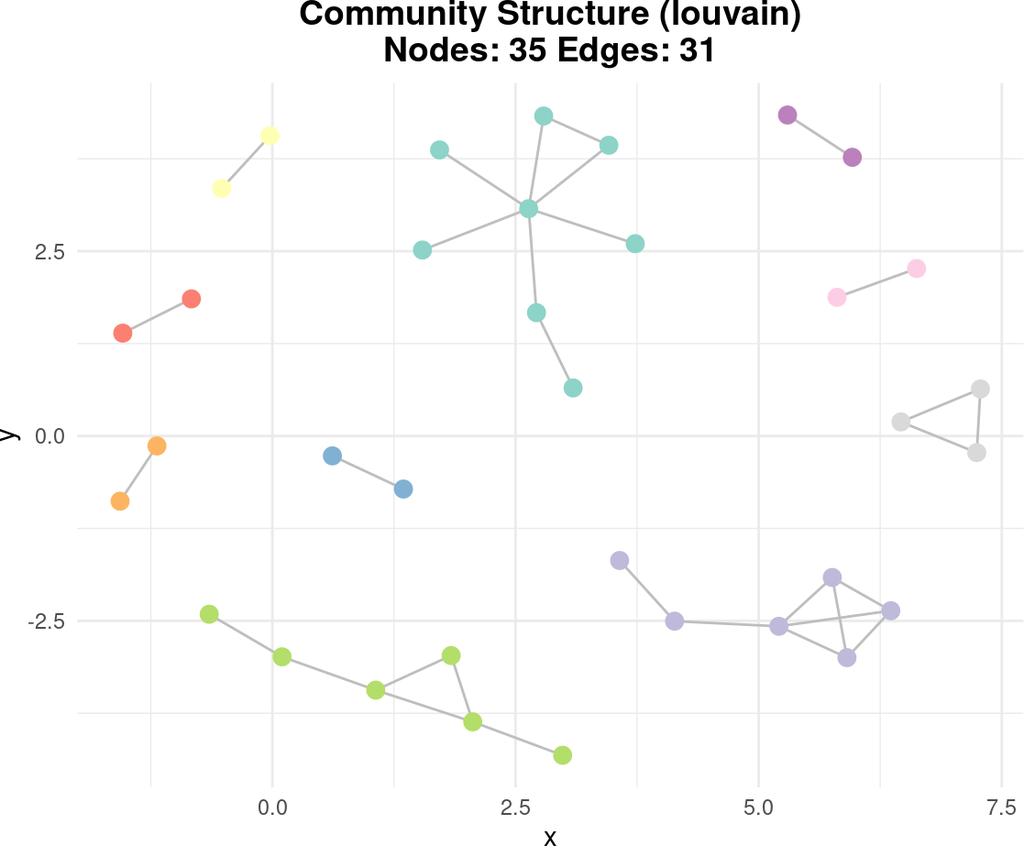

```
#> Running pathway enrichment...
```

```r
if (requireNamespace("igraph", quietly = TRUE)) {
    comm_truth <- community_path(adj_truth)
}
```

```
#> Detecting communities...
```

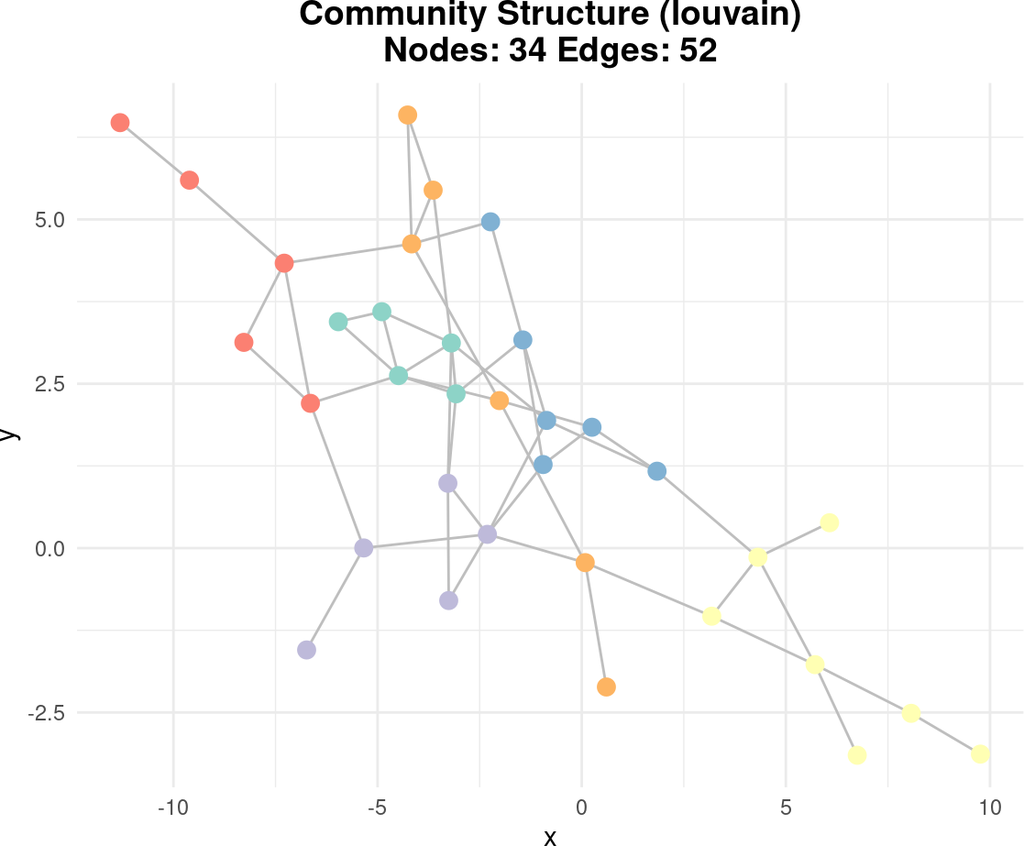

```
#> Running pathway enrichment...
```

```r
# Detect communities in consensus network
if (requireNamespace("igraph", quietly = TRUE)) {
    comm_cons <- community_path(consensus)
}
```

Finally, we’ll quantify how similar the community structures are between our inferred consensus network and the ground-truth network using the broken-down functions:

```
#>                  VI       NMI       ARI
#> Predicted_1 1.51592 0.6206409 0.2755744
#> $topology_measures
#>             Modularity Communities    Density Transitivity
#> Predicted_1  0.5218195           7 0.08739496    0.1678322
#>
#> $control_topology
#>   Modularity  Communities      Density Transitivity
#>   0.81373569  10.00000000   0.05210084   0.46666667
```

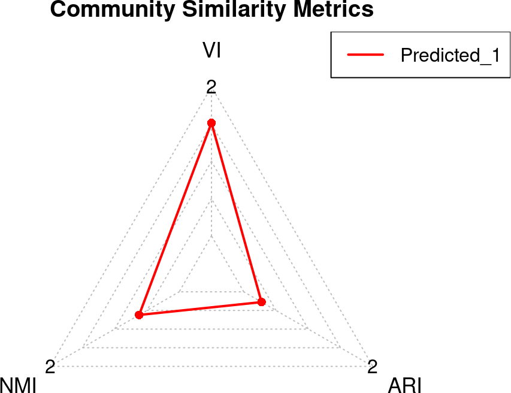

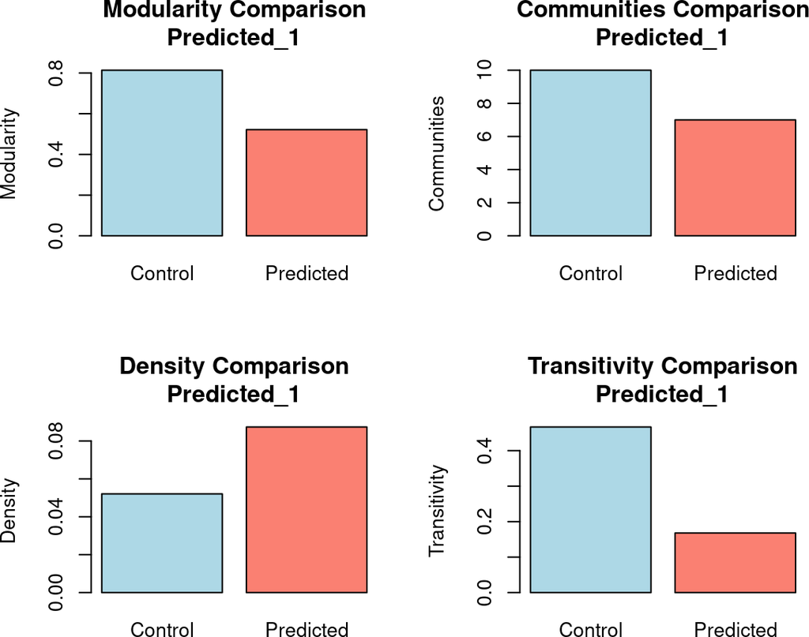

```r
# Calculate community metrics (VI, NMI, ARI)
if (requireNamespace("igraph", quietly = TRUE)) {
    comm_metrics <- compute_community_metrics(comm_truth, list(comm_cons))
    print(comm_metrics)

    # Calculate topology metrics (modularity, density, etc.)
    # Note: compute_topology_metrics expects community_path outputs
    # Returns a list with $topology_measures and $control_topology
    topo_metrics <- compute_topology_metrics(comm_truth, list(comm_cons))
    print(topo_metrics)

    # Visualize community comparison
    if (requireNamespace("fmsb", quietly = TRUE)) {
        plot_community_comparison(
            community_metrics = comm_metrics,
            topology_measures = topo_metrics$topology_measures,
            control_topology = topo_metrics$control_topology
        )
    }
}
```

## 7.1 5.1. Edge Mining

Edge mining provides a detailed analysis of network reconstruction performance by categorizing each predicted edge as True Positive (TP), False Positive (FP), True Negative (TN), or False Negative (FN). This gives us insight into which specific regulatory relationships were successfully recovered. The function now returns a list of dataframes matching the documentation.

**Edge Mining Analysis:** - **True Positives (TP)**: Correctly predicted edges that exist in ground truth - **False Positives (FP)**: Incorrectly predicted edges not in ground truth - **False Negatives (FN)**: Missed edges that exist in ground truth - **True Negatives (TN)**: Correctly identified non-edges

```r
em <- edge_mining(
    consensus,
    ground_truth = adj_truth,
    query_edge_types = "TP"
)
head(em[[1]])
```

```
#>    gene1 gene2 edge_type pubmed_hits
#> 2  ACTG1 ARPC3        TP           1
#> 4   CD3D  CD3E        TP          60
#> 5  ACTG1  CFL1        TP           5
#> 6 COX4I1 COX7C        TP           2
#> 7   CD74 CXCR4        TP         136
#> 8 EEF1A1 EEF1D        TP           6
#>                                                                                                                                                                                                                                                                                                          …
#> 2                                                                                                                                                                                                                                                                                                        …
#> 4                                                                                                                                                                                                                                                                                                        …
#> 5                                                                                                                                                                                                                                                                                                        …
#> 6                                                                                                                                                                                                                                                                                                        …
#> 7 40952055,40951943,40948762,40932351,40913267,40831537,40796616,40766141,40740771,40736341,40682854,40575951,40421217,40356050,40342960,40255236,40186663,40066443,40055309,40018995,39915484,39914814,39834330,39712016,39691708,39633216,39502000,39351536,39345457,39323959,39323779,39111632,3908440…
#> 8                                                                                                                                                                                                                                                                                                        …
#>   query_status
#> 2   hits_found
#> 4   hits_found
#> 5   hits_found
#> 6   hits_found
#> 7   hits_found
#> 8   hits_found
```